# Calculate grain size percentiles for Emerson data

## Purpose

The purpose of this script is to calculate the D16, D50 and D84 values for the data Emerson collected. The method I decided to use is to interpolate a straight line between Emerson’s points, and report the size (mm) where that interpolated line crossed the desired percentile (% finer than).

## Load data and libraries

**Note: we believe the Emerson data needs to be shifted to one category smaller (i.e. 45mm –> 32mm)**

```r
library(tidyverse)
library(ggplot2)
emerson.dat <- read.csv('Data/grainsize/Emerson_rawcounts_20190222.csv') %>%
  group_by(xs, position) %>%
  mutate(size_shift = lead(size, 1), # shift size category by 1
         size_shift = ifelse(is.na(size_shift),
                             4,
                             size_shift)) %>%
  select(-size) %>%
  rename(size = size_shift) %>%
  ungroup()
str(emerson.dat, give.attr = F)
```

```
Classes ‘tbl_df’, ‘tbl’ and 'data.frame':   390 obs. of  4 variables:
 $ xs         : int  1 1 1 1 1 1 1 1 1 1 ...
 $ position   : Factor w/ 3 levels "inner","middle",..: 1 1 1 1 1 1 1 1 1 1 ...
 $ prcnt_finer: int  100 100 100 96 78 41 16 9 2 1 ...
 $ size       : num  362 256 180 128 90 64 45 32 22.6 16 ...
```

## Quick plot of data

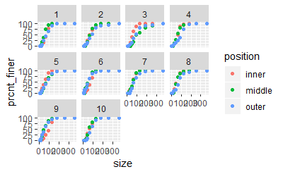

```r
ggplot(emerson.dat,
       aes(size, prcnt_finer, color = position)) +
  geom_point() +
  facet_wrap(~xs)
```

## Find gransize at percentiles

Create a function which interpolates a straight line between the two points nearest to the desired percentile `Dx`. Using the data provided by Emerson, the function looks for the minimum grain size where the percent finer is greater than `Dx`. Then it calculates the slope between those two lines. From here, it uses the slope and the `rise` to get to 50% to calculate a `run` (distance on the x-axis `grain size` we need to move from the known point to `D50`).

```r
calculate_dx <- function(dx) {
  'Purpose: Calculate the grainsize for a given percentile
  Method: Interpolate a straight line between the two bounding point
  Input: Desired percentile
  Output: Grainsize at desired percentile'
  emerson.dat %>%
    group_by(xs, position) %>%
    mutate(abovex = min(size[prcnt_finer > dx]),
           lessx = max(size[prcnt_finer <= dx])) %>%
    filter(size %in% c(abovex, lessx)) %>%
    mutate(slope = (max(prcnt_finer) - min(prcnt_finer)) / (max(size) - min(size))) %>%
    filter(size == lessx) %>%
    mutate(run = (dx - prcnt_finer) / slope,
           dx_size = size + run,
           dx = dx) %>%
    select(xs, position, dx, dx_size)
}
```

Once we have this function set up, loop through D16, D50 and D84, `join` those results together and write to a csv `write.csv`.

Also join in the attribute table from `rrGSDbendPts2015.shp` (which I exported here as a `.csv` file) to get the unique identifier `ET_ID`.

```r
dxs <- c(16, 50, 84) # choose which percentiles to calculate (e.g. D16, D50, D84)
results <- lapply(dxs,
               calculate_dx) %>%
  do.call(rbind, . ) %>%
  mutate(dx = paste0('D', dx)) %>%
  spread(dx, dx_size) %>%
  left_join(read.csv('Data/grainsize/rrGSDbendPts2015.csv') %>%
              select(xs, position, ET_ID))
head(results)
```

| xs | position | D16 | D50 | D84 | ET_ID |
| --- | --- | --- | --- | --- | --- |
| 1 | inner | 45.00000 | 70.32432 | 102.66667 | 0 |
| 1 | middle | 29.10769 | 51.67568 | 77.68421 | 10 |
| 1 | outer | 38.15789 | 71.58333 | 118.08696 | 11 |
| 2 | inner | 36.87500 | 65.08333 | 112.00000 | 13 |
| 2 | middle | 40.66667 | 67.15152 | 102.66667 | 12 |
| 2 | outer | 43.37500 | 84.52632 | 133.77778 | 1 |

```r
write.csv(results, 'Emerson_processed_dat.csv')
```

## Plot of results

#### As a test to make sure this went well, plot up the calculated `D50` vs the observed data.

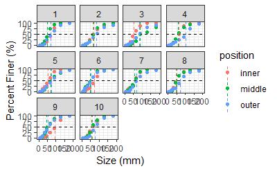

```r
emerson.dat %>%
  left_join(results) %>%
  ggplot() +
  theme_bw() +
  geom_point(aes(size, prcnt_finer, color = position)) +
  facet_wrap(~xs) +
  geom_hline(yintercept = 50, lty = 2) +
  geom_vline(aes(xintercept = D50, color = position), lty = 2) +
  lims(x = c(0,200)) +
  labs(x = 'Size (mm)', y = 'Percent Finer (%)')
```

```r
#ggsave('Emerson_D50.jpg', width = 10, height = 8, dpi = 300)#pdfs 10x10
```

#### One more test of the `D84`

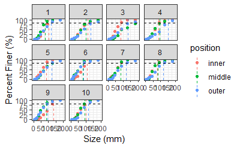

```r
emerson.dat %>%
  left_join(results) %>%
  ggplot() +
  theme_bw() +
  geom_point(aes(size, prcnt_finer, color = position)) +
  facet_wrap(~xs) +
  geom_hline(yintercept = 84, lty = 2) +
  geom_vline(aes(xintercept = D84, color = position), lty = 2) +
  lims(x = c(0,200)) +
  labs(x = 'Size (mm)', y = 'Percent Finer (%)')
```

## Next steps

From here the plan is to join the `D50` and `D84` from the Emerson data with the shapefile of pebble count locations from Lee. From there we will create a TIN and DEM interpolated raster of `D50` and `D84` for the entire wetted channel of the Robinson Ranch.